# PAS3 Analysis

# Range Sensitivity

This is a value-representation test, not an attention test. The question is whether a given value difference moves choice more in the Narrow range than the Wide range. We regress choice on the per-type signed value channels (`SV_P/SV_N/SV_B`) and interact each with the range condition. Range normalization predicts the slope of choice on value is steeper in Narrow, so each `SV_type:WNWide` interaction should be negative (value drives choice less when the range is wide).

```r
# Signed value summed per type (SV_P, SV_N, SV_B): how much each attribute type's
# value difference favors the left option. Built from value only -- no dwell time.
# (value_design was already constructed above; rebuilt here so this section is
# self-contained.)
value_design <- boxlong %>%
  group_by(Subject, Trial, type) %>%
  summarise(SV = sum(signed_value), .groups = "drop") %>%
  pivot_wider(names_from = type, values_from = SV,
              names_prefix = "SV_", values_fill = 0)

val_dat <- pas %>%
  select(Subject, Trial, ChooseL, WN) %>%
  left_join(value_design, by = c("Subject", "Trial"))
```

```r
# Population value sensitivity per type, interacted with range; subjects get
# heterogeneous value sensitivity via random slopes.
val_fit <- brm(
  ChooseL ~ (SV_P + SV_N + SV_B) * WN + (1 + SV_P + SV_N + SV_B | Subject),
  data    = val_dat, family = bernoulli(),
  prior   = c(prior(normal(0, 2.5), class = "b"),
              prior(normal(0, 2),   class = "Intercept")),
  chains  = BRMS_CHAINS, iter = BRMS_ITER, seed = BRMS_SEED,
  control = list(adapt_delta = 0.95),
  file    = "brm_fits/value_sensitivity_by_range"
)
val_fit
```

```
##  Family: bernoulli
##   Links: mu = logit
## Formula: ChooseL ~ (SV_P + SV_N + SV_B) * WN + (1 + SV_P + SV_N + SV_B | Subject)
##    Data: val_dat (Number of observations: 28646)
##   Draws: 4 chains, each with iter = 2000; warmup = 1000; thin = 1;
##          total post-warmup draws = 4000
##
## Multilevel Hyperparameters:
## ~Subject (Number of levels: 981)
##                     Estimate Est.Error l-95% CI u-95% CI Rhat Bulk_ESS Tail_ESS
## sd(Intercept)           0.04      0.03     0.00     0.12 1.04      100      215
## sd(SV_P)                0.65      0.03     0.58     0.71 1.00     1349     2300
## sd(SV_N)                0.64      0.03     0.58     0.71 1.00      856     1633
## sd(SV_B)                0.62      0.03     0.55     0.68 1.00      902     1520
## cor(Intercept,SV_P)     0.06      0.29    -0.43     0.68 1.10       38       37
## cor(Intercept,SV_N)     0.23      0.31    -0.45     0.81 1.24       13       39
## cor(SV_P,SV_N)          0.68      0.04     0.60     0.74 1.00     1109     2307
## cor(Intercept,SV_B)     0.10      0.37    -0.58     0.80 1.39        9       28
## cor(SV_P,SV_B)          0.59      0.04     0.50     0.67 1.00     1093     2240
## cor(SV_N,SV_B)          0.58      0.04     0.49     0.66 1.00     1141     2401
##
## Regression Coefficients:
##             Estimate Est.Error l-95% CI u-95% CI Rhat Bulk_ESS Tail_ESS
## Intercept      -0.02      0.02    -0.06     0.02 1.00     6395     3591
## SV_P            2.10      0.05     2.00     2.20 1.00     1356     1576
## SV_N            1.92      0.05     1.82     2.02 1.00     1426     1960
## SV_B            1.84      0.05     1.75     1.93 1.00     1437     1971
## WNWide          0.04      0.03    -0.02     0.10 1.00     5782     3118
## SV_P:WNWide    -0.55      0.06    -0.67    -0.42 1.00     1406     2096
## SV_N:WNWide    -0.46      0.06    -0.58    -0.34 1.00     1344     1931
## SV_B:WNWide    -0.29      0.06    -0.41    -0.18 1.00     1525     2459
##
## Draws were sampled using sample(hmc). For each parameter, Bulk_ESS
## and Tail_ESS are effective sample size measures, and Rhat is the potential
## scale reduction factor on split chains (at convergence, Rhat = 1).
```

```r
vd <- as_draws_df(val_fit)

summ <- function(x) {
  h <- bayestestR::hdi(x, ci = 0.95)
  tibble(estimate = median(x), hdi_low = h$CI_low, hdi_high = h$CI_high,
         p_neg = mean(x < 0))
}

# Per-type: Narrow slope, Wide slope, and the Wide-minus-Narrow range effect.
# WN reference is Narrow, so b_SV_type is the Narrow slope and
# b_SV_type:WNWide is (Wide slope - Narrow slope).
slope_tbl <- map_dfr(c("N", "B", "P"), function(tt) {
  narrow <- vd[[paste0("b_SV_", tt)]]
  inter  <- vd[[paste0("b_SV_", tt, ":WNWide")]]
  wide   <- narrow + inter
  bind_rows(
    summ(narrow) %>% mutate(quantity = "1_slope_Narrow"),
    summ(wide)   %>% mutate(quantity = "2_slope_Wide"),
    summ(inter)  %>% mutate(quantity = "3_Wide_minus_Narrow")
  ) %>% mutate(type = tt)
}) %>%
  transmute(type = factor(type, levels = c("N", "B", "P")), quantity,
            estimate = round(estimate, 3),
            HDI = sprintf("[%.3f, %.3f]", hdi_low, hdi_high),
            Pr_lt_0 = round(p_neg, 2)) %>%
  arrange(type, quantity)

slope_tbl
```

```
## # A tibble: 9 × 5
##   type  quantity            estimate HDI              Pr_lt_0
##   <fct> <chr>                  <dbl> <chr>              <dbl>
## 1 N     1_slope_Narrow         1.92  [1.817, 2.010]         0
## 2 N     2_slope_Wide           1.46  [1.371, 1.533]         0
## 3 N     3_Wide_minus_Narrow   -0.46  [-0.572, -0.336]       1
## 4 B     1_slope_Narrow         1.84  [1.755, 1.931]         0
## 5 B     2_slope_Wide           1.55  [1.470, 1.632]         0
## 6 B     3_Wide_minus_Narrow   -0.29  [-0.405, -0.175]       1
## 7 P     1_slope_Narrow         2.10  [2.003, 2.201]         0
## 8 P     2_slope_Wide           1.56  [1.473, 1.637]         0
## 9 P     3_Wide_minus_Narrow   -0.547 [-0.670, -0.422]       1
```

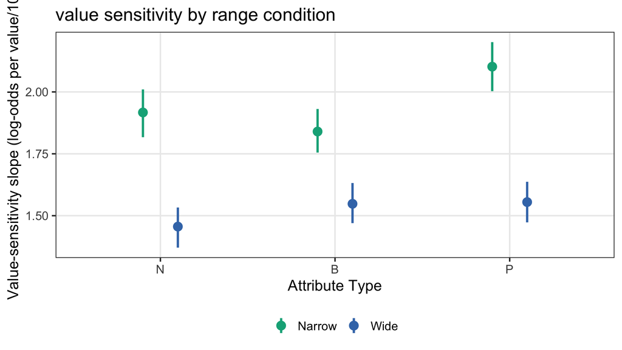

```r
# Narrow vs Wide value-sensitivity slope per type, with 95% HDI.
plot_dat <- slope_tbl %>%
  filter(quantity %in% c("1_slope_Narrow", "2_slope_Wide")) %>%
  mutate(WN = if_else(quantity == "1_slope_Narrow", "Narrow", "Wide"),
         lo = as.numeric(str_extract(HDI, "(?<=\\[)[-0-9.]+")),
         hi = as.numeric(str_extract(HDI, "(?<=, )[-0-9.]+")))

ggplot(plot_dat, aes(x = type, y = estimate, color = WN)) +
  geom_pointrange(aes(ymin = lo, ymax = hi),
                  position = position_dodge(width = 0.4), linewidth = 1) +
  scale_color_manual(values = plt$wn_colors) +
  labs(x = "Attribute Type", y = "Value-sensitivity slope (log-odds per value/10)",
       title = "value sensitivity by range condition", color = NULL) +
  theme(legend.position = "bottom")
```